# Final_Group3

Alexis McCartney, Marvelle Horton, Kristen Durkin

2025-12-10

# Process

Load Data -> Clean Data -> Scale Data -> Split Data -> Pick K -> Run K -> Analysis -> Visuals

# Load Data

This file contains the YTD variables we will use for clustering for 2023.

```r
df <- read.csv("Group3Data.csv") #read csv file
View(df) #Visual Check
```

# Step 1: Remove variables that have significant missing values

Check and see if there are any values missing in each column:

```r
colSums(is.na(df)) #Count N/A values in each column
```

```
## U.S..Department.of.Energy..The.Energy.Information.Administration..EIA.
##                                                                      0
##                                                                      X
##                                                                      0
##                                                                    X.1
##                                                                      0
##                                                                    X.2
##                                                                      0
##                                                                    X.3
##                                                                      0
##                                                                    X.4
##                                                                      0
##                                                                    X.5
##                                                                      0
##                                                                    X.6
##                                                                      0
##                                                                    X.7
##                                                                      0
##                                                                    X.8
##                                                                      0
##                                                                    X.9
##                                                                      0
##                                                                   X.10
##                                                                      0
##                                                                   X.11
##                                                                      0
##                                                                   X.12
##                                                                      0
##                                                                   X.13
##                                                                      0
##                                                                   X.14
##                                                                      0
##                                                                   X.15
##                                                                     19
##                                                                   X.16
##                                                                      0
##                                                                   X.17
##                                                                      0
##                                                                   X.18
##                                                                      0
```

[output cut: 139 more lines]

```
##                                                                      0
##                                                                   X.89
##                                                                      0
##                                                                   X.90
##                                                                      0
##                                                                   X.91
##                                                                      0
##                                                                   X.92
##                                                                      0
##                                                                   X.93
##                                                                      0
##                                                                   X.94
##                                                                      0
##                                                                   X.95
##                                                                      0
```

Returned data does not show significant missing values for the YTD variables.

# Step 2: Focus on last 6 YTD column

(First we count all the columns then select the last 6)

```r
num_cols <- ncol(df)   #total columns
ytd <- df[, (num_cols-5):num_cols] #grab last 6 columns (YTD data)
head(ytd)
```

|  | X.90 | X.91 | X.92 | X.93 | X.94 | X.95 |
| --- | --- | --- | --- | --- | --- | --- |
| 1 |  |  |  |  |  |  |
| 2 |  |  |  |  |  |  |
| 3 |  |  |  |  |  |  |
| 4 | Year-To-Date |  |  |  |  |  |
| 5 | Total Fuel Consumption\nQuantity | Electric Fuel Consumption\nQuantity | Total Fuel Consumption\nMMBtu | Elec Fuel Consumption\nMMBtu | Net Generation\n(Megawatthours) | YEAR |
| 6 | 4,962 | 4,962 | 29,007 | 29,007 | 2,748 | 2023 |

```r
colSums(is.na(ytd)) #double check for missing values
```

```
## X.90 X.91 X.92 X.93 X.94 X.95
##    0    0    0    0    0    0
```

Results show that the YTD columns do not have any missing values.

YTD Columns: X.90 = Total Fuel Consumption Quantity X.91 = Electric Fuel Consumption Quantity X.92 = Total Fuel Consumption MMBtu X.93 = Elec Fuel Consumption MMBtu X.94 = Net Generation (Megawatthours) X.95 = YEAR

# Step 3: Remove YEAR from clustering data since it’s constant

```r
ytd_noyear <- ytd[, c("X.90", "X.91", "X.92", "X.93", "X.94")] #Drop YEAR column since it's constant
head(ytd_noyear) #confirm remaining columns
```

|  | X.90 | X.91 | X.92 | X.93 | X.94 |
| --- | --- | --- | --- | --- | --- |
| 1 |  |  |  |  |  |
| 2 |  |  |  |  |  |
| 3 |  |  |  |  |  |
| 4 | Year-To-Date |  |  |  |  |
| 5 | Total Fuel Consumption\nQuantity | Electric Fuel Consumption\nQuantity | Total Fuel Consumption\nMMBtu | Elec Fuel Consumption\nMMBtu | Net Generation\n(Megawatthours) |
| 6 | 4,962 | 4,962 | 29,007 | 29,007 | 2,748 |

# Step 4: Remove any non-numerical data from the set

```r
ytd_clean <- ytd_noyear[!is.na(as.numeric(ytd_noyear$X.90)), ] #keep only numerical rows
head(ytd_clean) #check the cleaned data
```

|  | X.90 | X.91 | X.92 | X.93 | X.94 |
| --- | --- | --- | --- | --- | --- |
| 7 | 577 | 577 | 3,373 | 3,373 | 319 |
| 8 | 0 | 0 | 672 | 672 | 183 |
| 9 | 0 | 0 | 174 | 174 | 51 |
| 10 | 0 | 0 | 473,183 | 473,183 | 138,682 |
| 15 | 0 | 0 | 0 | 0 | 0 |
| 16 | 0 | 0 | 1,755,486 | 1,755,486 | 514,504 |

# Step 5: Remove any special characters like commas

```r
ytd_clean <- as.data.frame(lapply(ytd_clean, function(x) as.numeric(gsub(",", "", x)))) #remove special characters
str(ytd_clean)
```

```
## 'data.frame':    12301 obs. of  5 variables:
##  $ X.90: num  577 0 0 0 0 0 0 0 0 0 ...
##  $ X.91: num  577 0 0 0 0 0 0 0 0 0 ...
##  $ X.92: num  3373 672 174 473183 0 ...
##  $ X.93: num  3373 672 174 473183 0 ...
##  $ X.94: num  319 183 51 138682 0 ...
```

Now the data is all numerical & clean.

# Step 6: Scale the data

We scale so that all features contribute equally to the k-means distance calculation.

```r
ytd_scaled <- scale(ytd_clean)
head(ytd_scaled)
```

```
##            X.90       X.91        X.92        X.93         X.94
## [1,]  4.8286914  5.0733614 -0.11476895 -0.11476728 -0.177458927
## [2,] -0.2250483 -0.2195277 -0.11511610 -0.11511442 -0.177626510
## [3,] -0.2250483 -0.2195277 -0.11518011 -0.11517843 -0.177789163
## [4,] -0.2250483 -0.2195277 -0.05438652 -0.05438485 -0.006964982
## [5,] -0.2250483 -0.2195277 -0.11520247 -0.11520079 -0.177852006
## [6,] -0.2250483 -0.2195277  0.11042176  0.11042340  0.456131190
```

```r
str(ytd_scaled) #confirm data is all numbers
```

```
##  num [1:12301, 1:5] 4.829 -0.225 -0.225 -0.225 -0.225 ...
##  - attr(*, "dimnames")=List of 2
##   ..$ : NULL
##   ..$ : chr [1:5] "X.90" "X.91" "X.92" "X.93" ...
##  - attr(*, "scaled:center")= Named num [1:5] 25.7 23.9 896341.3 896328.4 144334.4
##   ..- attr(*, "names")= chr [1:5] "X.90" "X.91" "X.92" "X.93" ...
##  - attr(*, "scaled:scale")= Named num [1:5] 114 109 7780574 7780575 811542
##   ..- attr(*, "names")= chr [1:5] "X.90" "X.91" "X.92" "X.93" ...
```

Scaling makes our mean roughly 0 and standard deviation roughly 1 (z-scores)

```r
colMeans(ytd_scaled) #Confirmation of scale
```

```
##          X.90          X.91          X.92          X.93          X.94
##  1.252792e-17  1.221428e-17 -2.859946e-19 -8.055091e-18 -1.191475e-17
```

```r
apply(ytd_scaled, 2, sd) #Confirmation of standard deviation
```

```
## X.90 X.91 X.92 X.93 X.94
##    1    1    1    1    1
```

# Step 7: Split into training/test data sets

Split the scaled dataset into a training set (75% of observations) and a test set (25%). The training set will be used to determine the optimal number of clusters and to build the k-means segmentation.

```r
set.seed(123)
n <- nrow(ytd_scaled)
train_idx <- sample(1:n, size = 0.75 * n) #randomly select 75% of data for training

train <- ytd_scaled[train_idx, ] #training set
test <- ytd_scaled[-train_idx, ] #test set

dim(train) #check training dimensions
```

```
## [1] 9225    5
```

```r
dim(test) #check test dimensions
```

```
## [1] 3076    5
```

Confirmation: data is split.

# Step 8: Elbow Plot

The elbow method helps determine the number of clusters by plotting the total within-cluster sum of squares (WSS) for different values of k.

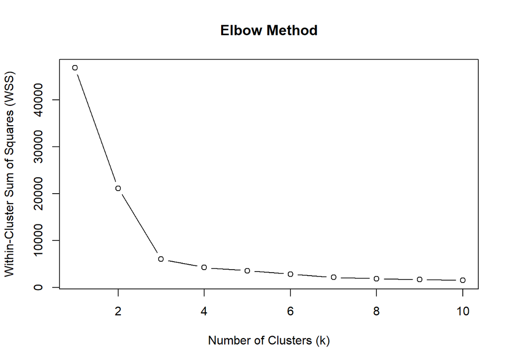

```r
wss <- sapply(1:10, function(k) {
  kmeans(train, centers = k, nstart = 20)$tot.withinss #get total WSS for each k
})

plot(1:10, wss, type = "b",
     xlab = "Number of Clusters (k)",
     ylab = "Within-Cluster Sum of Squares (WSS)",
     main = "Elbow Method")
```

```r
#look where elbow - this shows when adding more would not be benefical
```

Results:

Cluster 1 = very high WSS with everything lumped together. k = 2 = largest change. k = 3 = “elbow” point.

Using the elbow method,a clear bend at k = 3 can be seen. While the WSS decreases sharply from k = 1 to k = 3, the reduction beyond k = 3 is minimal. This indicates that 3 clusters provide an ideal balance.

# Step 9: Silhouette (Confirmation)

```r
library(cluster)
```

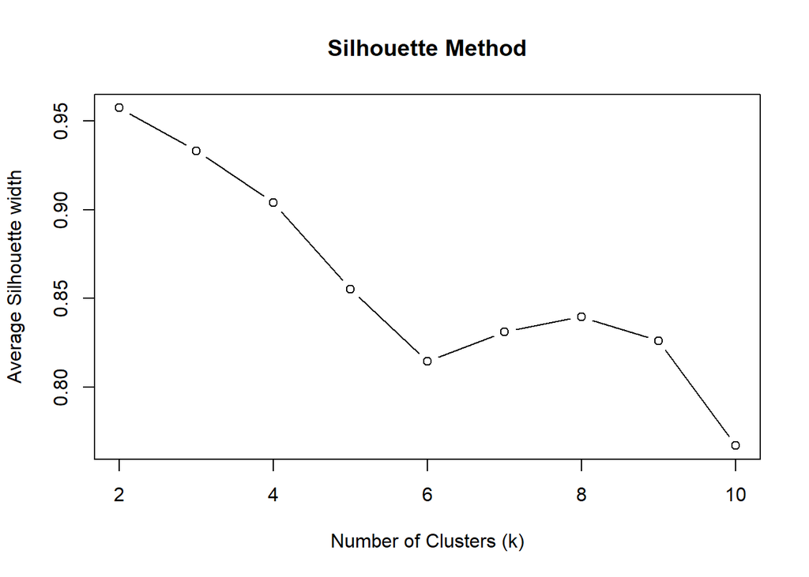

```r
avg_sil <- sapply(2:10, function(k){
  km <- kmeans(train, centers = k, nstart = 20) #Run k means
  ss <- silhouette(km$cluster, dist(train)) #run silhouette for clustering
  mean(ss[, 3]) #avg silhouette for k
  })

plot(2:10, avg_sil, type = "b",
    xlab = "Number of Clusters (k)",
    ylab = "Average Silhouette width",
    main = "Silhouette Method")
```

```r
#Higher values mean more defined clusters
```

Confirmation k = 3

Based on the elbow method, it’s observed to have a clear bend at k = 3, indicating diminishing returns beyond this point. Although the silhouette method peaked at k = 2, the value for k = 3 remained high, suggesting well separated clusters.

For this reason we selected k = 3 as the optimal number of clusters.

# Step 10: Run K-means with k = 3

Now we actually run the final clustering model using k = 3.

```r
set.seed(123)
km_final <- kmeans (train, centers = 3, nstart = 25) #final k means model

km_final$size #how many plants are in each cluster
```

```
## [1] 8845  308   72
```

```r
km_final$centers #cluster center scaled
```

```
##         X.90       X.91        X.92        X.93        X.94
## 1 -0.1671690 -0.1643987 -0.08400851 -0.08400731 -0.07659297
## 2  4.8973956  4.8452545 -0.11489970 -0.11492738 -0.17330537
## 3 -0.2250483 -0.2195277 11.09621193 11.09621148 10.39407454
```

# Step 11: Cluster Interpretation

Cluster sizes: Cluster 1: 8845 plants Cluster 2: 308 plants Cluster 3: 72 plants

Cluster 1 -> Low values

Slightly lower than average fuel use Slightly lower than average heat content Slightly lower electricity generation

Cluster 1 contains units with below average fuel consumption and below average electricity generation. This suggests these units operate at relatively low levels of activity compared to the rest of the dataset.

Cluster 3 -> high values

# Step 12: Add IDs and Visualize

Now we attach the cluster labels back to the training data and plot the clusters.

```r
train_clusters <- as.data.frame(train) #transition from training to data frame
train_clusters$cluster <- km_final$cluster #add labels to clusters
head(train_clusters) #data preview
```

|  | X.90 | X.91 | X.92 | X.93 | X.94 | cluster |
| --- | --- | --- | --- | --- | --- | --- |
| 1 | -0.2250483 | -0.2195277 | -0.1152025 | -0.1152008 | -0.1778520 | 1 |
| 2 | -0.2250483 | -0.2195277 | -0.1152025 | -0.1152008 | -0.1575093 | 1 |
| 3 | -0.2250483 | -0.2195277 | -0.1135647 | -0.1135630 | -0.1732497 | 1 |
| 4 | 0.3792984 | 0.4134175 | -0.1151511 | -0.1151494 | -0.1778027 | 1 |
| 5 | -0.2250483 | -0.2195277 | -0.1015800 | -0.1015783 | -0.1395743 | 1 |
| 6 | -0.2250483 | -0.2195277 | -0.1051805 | -0.1051788 | -0.1496908 | 1 |

```r
library(factoextra) #package for easy k-means cluster visualizations
```

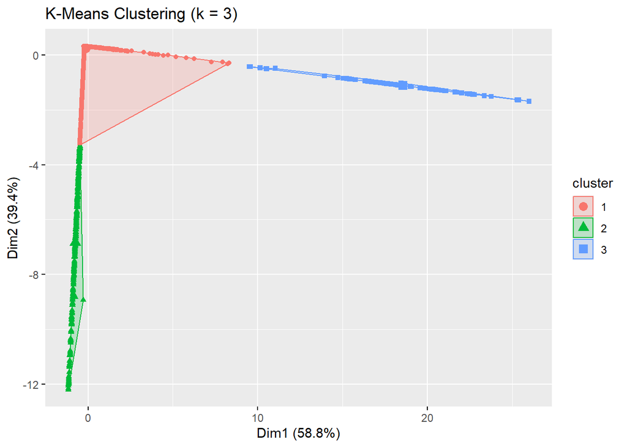

```r
fviz_cluster(
  list(data = train, cluster = km_final$cluster),
  geom = "point", #show each plant as a point
  ellipse.type = "convex", # draw convex hulls around clusters (Mod 6)
  main = "K-Means Clustering (k = 3)"
)
```

```r
# This visual reduces our 5 scaled variables into a 2D space so we can actually see how well the clusters separate.
# The convex ellipses help outline the grouping structure,which is exactly how we learned to interpret cluster quality in mod 6.
```